# Sleep

Stage composition, architecture trends, and sleep debt across 13 months

```r
source("R/load_data.R")
library(patchwork)
library(tidyr)
```

Sleep architecture — the nightly mix of light, deep (slow-wave), and REM sleep — reflects both physiological need and recovery quality. The analyses here treat each night as a functional observation and look at how the composition changed over time.

## Monthly sleep stage composition

Modeled after the COVID mortality composition plots in the FDA textbook, this stacked bar chart shows how average nightly sleep stage proportions shifted month to month.

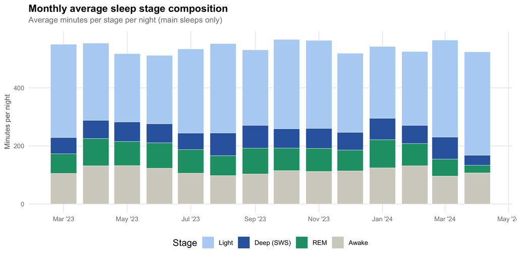

```r
monthly_sleep |>
  pivot_longer(cols = c(light_avg, deep_avg, rem_avg, awake_avg),
               names_to = "stage", values_to = "minutes") |>
  mutate(
    stage = recode(stage,
      light_avg = "Light", deep_avg = "Deep (SWS)",
      rem_avg   = "REM",   awake_avg = "Awake"
    ) |> factor(levels = c("Light", "Deep (SWS)", "REM", "Awake"))
  ) |>
  ggplot(aes(x = month, y = minutes, fill = stage)) +
  geom_col(width = 25, color = "white", linewidth = 0.2) +
  scale_fill_manual(
    values = c(
      "Light"       = "#B5D4F4",
      "Deep (SWS)"  = "#3266ad",
      "REM"         = "#1D9E75",
      "Awake"       = "#D3D1C7"
    ),
    name = "Stage"
  ) +
  scale_x_date(date_breaks = "2 months", date_labels = "%b '%y") +
  labs(
    title    = "Monthly average sleep stage composition",
    subtitle = "Average minutes per stage per night (main sleeps only)",
    x = NULL, y = "Minutes per night"
  ) +
  theme_whoop()
```

## Deep sleep and REM over time

Deep sleep (slow-wave sleep) is critical for physical recovery; REM is linked to cognitive consolidation. Here we track their 4-week rolling means separately.

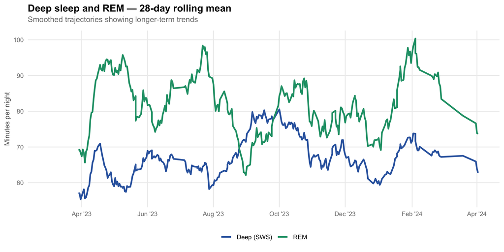

4-week rolling mean of nightly deep and REM sleep (minutes). Both series are smoothed to reduce nightly noise. Deep sleep shows a gradual upward trend through mid-2023; REM peaks in January 2024.

```r
main_sleeps |>
  filter(!is.na(deep_min), !is.na(rem_min)) |>
  arrange(date) |>
  mutate(
    deep_roll = rollmean(deep_min, 28, fill = NA, align = "right", na.rm = TRUE),
    rem_roll  = rollmean(rem_min,  28, fill = NA, align = "right", na.rm = TRUE)
  ) |>
  pivot_longer(cols = c(deep_roll, rem_roll), names_to = "metric", values_to = "minutes") |>
  mutate(metric = recode(metric, deep_roll = "Deep (SWS)", rem_roll = "REM")) |>
  ggplot(aes(x = date, y = minutes, color = metric)) +
  geom_line(linewidth = 1.1, na.rm = TRUE) +
  scale_color_manual(values = c("Deep (SWS)" = "#3266ad", "REM" = "#1D9E75"), name = NULL) +
  scale_x_date(date_breaks = "2 months", date_labels = "%b '%y") +
  labs(
    title    = "Deep sleep and REM — 28-day rolling mean",
    subtitle = "Smoothed trajectories showing longer-term trends",
    x = NULL, y = "Minutes per night"
  ) +
  theme_whoop()
```

## Sleep efficiency distribution

Sleep efficiency = asleep time / time in bed. Values above 85% are generally considered good.

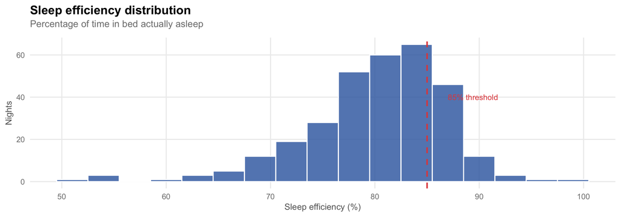

Distribution of sleep efficiency across all nights. The dashed line marks the 85% clinical threshold.

```r
main_sleeps |>
  filter(!is.na(sleep_eff)) |>
  ggplot(aes(x = sleep_eff)) +
  geom_histogram(binwidth = 3, fill = "#3266ad", color = "white", alpha = 0.8) +
  geom_vline(xintercept = 85, linetype = "dashed", color = "#E24B4A", linewidth = 0.8) +
  annotate("text", x = 87, y = 40, label = "85% threshold",
           color = "#E24B4A", size = 3.2, hjust = 0) +
  labs(
    title    = "Sleep efficiency distribution",
    subtitle = "Percentage of time in bed actually asleep",
    x = "Sleep efficiency (%)", y = "Nights"
  ) +
  theme_whoop()
```

## Sleep debt trajectory

WHOOP tracks cumulative sleep debt — how many minutes short of your sleep need you are. Sustained debt is associated with impaired recovery and performance.

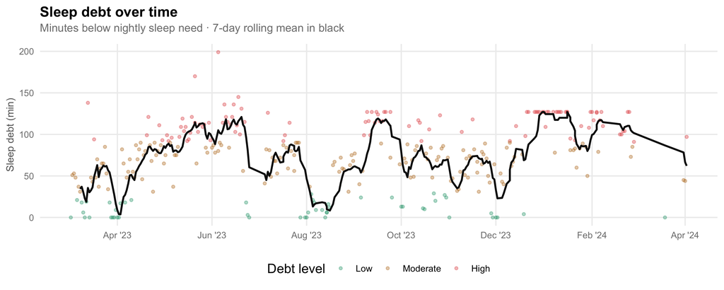

Daily sleep debt (points, colored by magnitude) with 7-day rolling mean. Peaks in debt often correspond to low-recovery periods seen in the Recovery page.

```r
main_sleeps |>
  filter(!is.na(sleep_debt)) |>
  arrange(date) |>
  mutate(
    debt_roll   = rollmean(sleep_debt, 7, fill = NA, align = "right", na.rm = TRUE),
    debt_zone   = case_when(
      sleep_debt <= 30  ~ "Low",
      sleep_debt <= 90  ~ "Moderate",
      TRUE              ~ "High"
    ) |> factor(levels = c("Low", "Moderate", "High"))
  ) |>
  ggplot(aes(x = date)) +
  geom_point(aes(y = sleep_debt, color = debt_zone), alpha = 0.35, size = 1.1) +
  geom_line(aes(y = debt_roll), color = "#111", linewidth = 0.9, na.rm = TRUE) +
  scale_color_manual(
    values = c(Low = "#1D9E75", Moderate = "#BA7517", High = "#E24B4A"),
    name = "Debt level"
  ) +
  scale_x_date(date_breaks = "2 months", date_labels = "%b '%y") +
  labs(
    title    = "Sleep debt over time",
    subtitle = "Minutes below nightly sleep need · 7-day rolling mean in black",
    x = NULL, y = "Sleep debt (min)"
  ) +
  theme_whoop()
```

## Sleep performance vs. next-day recovery

Does better sleep tonight predict better recovery tomorrow? We join sleep performance to the *following* day’s recovery score.

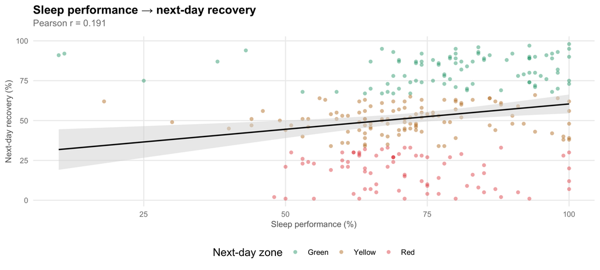

Sleep performance (%) on the x-axis vs. next-day recovery score on the y-axis. Each point is one night. The positive trend suggests sleep quality does predict next-day readiness, but with substantial scatter — recovery is multifactorial.

```r
sleep_lag <- main_sleeps |>
  filter(!is.na(sleep_perf)) |>
  select(date, sleep_perf) |>
  mutate(next_date = date + 1) |>
  left_join(cycles |> select(date, recovery, rec_zone), by = c("next_date" = "date")) |>
  filter(!is.na(recovery))

sleep_lag_cor <- cor(sleep_lag$sleep_perf, sleep_lag$recovery, use = "complete.obs") |> round(3)

ggplot(sleep_lag, aes(x = sleep_perf, y = recovery, color = rec_zone)) +
  geom_point(alpha = 0.45, size = 1.8, shape = 16) +
  geom_smooth(method = "lm", se = TRUE, color = "#111", linewidth = 0.8,
              fill = "grey85", alpha = 0.5) +
  scale_color_manual(
    values = c(Green = "#1D9E75", Yellow = "#BA7517", Red = "#E24B4A"),
    name = "Next-day zone"
  ) +
  labs(
    title    = "Sleep performance → next-day recovery",
    subtitle = paste0("Pearson r = ", sleep_lag_cor),
    x = "Sleep performance (%)", y = "Next-day recovery (%)"
  ) +
  theme_whoop()
```